# STAT 184 Homework Exercises

DataComputing Chapters 5 & 6

Haichen Wei

## Assigned Exercises

- DC Chapter 5 Exercises: 5.1
- DC Chapter 6 Exercises: 6.1 through 6.10

## Front Matter

```r
# clean up workspace environment
rm(list = ls())
# all packages used for the assignment
library(mosaic)
library(tidyverse)
```

## Chapter 5 Exercises

### Problem 5.1

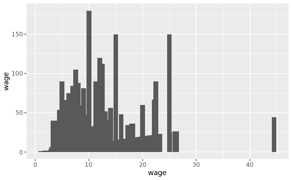

```r
library(mosaicData)
library(DataComputing)
barGraphHelper(CPS85)
```

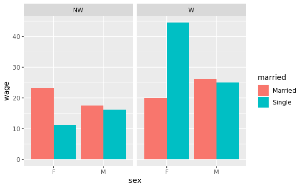

```r
ggplot(data=CPS85,aes(x=sex,y=wage,fill=married))+
  geom_bar(stat='identity',position='dodge', width=.9)+ facet_wrap(~race,ncol=3)
```

## Chapter 6 Exercises

### Problem 6.1

1. suspension growth and adhesion growth
2. Yes, the frames are the same
3. red line:suspension growth for different amounts of time black lines: adhesion growth starts

### Problem 6.2

1. log enzyme concentration: y axis, range from -3 to 5 flux:a filled dot or a hollow dot target: lines on top of the graph indicating the region in which each level gene: x axis. molecule: the different colors of the dot glyphs.
2. Color: different types of molecules Fill: describes whether the molecule has flux = 0 or flux > 0. Location: x-axis (gene type) and y-axis (log enzyme concentration)
3. Log enzyme concentration and gene
4. target and gene

### Problem 6.3

1. vertical lines: center,low,high star: polarity color: different types of protein
2. protein and cell density
3. Yes, color shows the dtfferent types of protein
4. Log2 ratio low vs high cell density, Apico-basal cell polarity proteins, color

### Problem 6.4

1. It’s a horizontal coordinate which uses time and modes of transportation to indicate the position.
2. It uses three coclors(red, yellow,blue) to indicate different modes of transportation.
3. The shape/style of the glyphs encodes modes of transportation. The position of the glyph encodes the time.
4. time and modes of transportation, color

### Problem 6.5

b

### Problem 6.6

d

### Problem 6.7

b

### Problem 6.8

a, e

### Problem 6.9

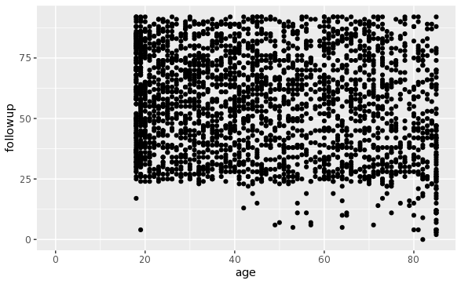

```r
Small <-
  NCHS %>%
  sample_n(size=5000)
  scatterGraphHelper(Small)
```

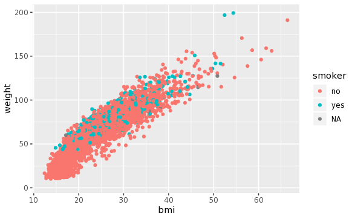

```r
  ggplot(data=Small,aes(x=bmi,y=weight))+geom_point()+aes(colour=smoker)
```

Variables: bmi, weight, smoker Attributes: bmi = x-axis, weight = y-axis, smoker = color

### Problem 6.10

1. The layer shows all the organisms, and some of them are overlapping
2. There is no scale in this graph.